# Uniwersytet Dzieci

Przemyslaw Biecek

29 January 2016

```r
library(knitr)
library(archivist)
library(ggplot2)
library(openxlsx)
library(scales)

# options for chunks
opts_chunk$set(comment=NA, fig.width=6, fig.height=6, results='asis', warning=FALSE, message=FALSE, cache=FALSE)

# store everything in the archivist repo
addArchivistHook(class=c("ggplot", "knitr_kable"),
                 repoDir = "arepo",
                 repo = "PieczaraPietraszki", user = "BetaAndBit", repoDirGit = "UniwersytetDzieci/arepo")
```

# Ssaki

Poniższa tabela i wykres przedstawiają zależnośc wielkości od masy różnych ssaków, od tych najmniejszych po najwięszke giganty. Zależność jest liniowa w skali log-log.

```r
ssaki <- read.xlsx("SSaki/ssaki.xlsx", 1)

print(kable(ssaki))
```

Load: [`archivist::aread('BetaAndBit/PieczaraPietraszki/UniwersytetDzieci/arepo/b6c209ccd451b54effaa4017e2bc6cae')`](https://github.com/BetaAndBit/PieczaraPietraszki/blob/master/UniwersytetDzieci/arepo/gallery/b6c209ccd451b54effaa4017e2bc6cae.rda?raw=true)

| Angielska.nazwa | Polska.nazwa | Wielkość.[cm] | Waga.[g] |
| --- | --- | --- | --- |
| Kitti’s hog-nosed bat | Świnionos malutki | 3 | 2.0e+00 |
| Wood mouse | Myszarka zaroślowa | 18 | 2.5e+01 |
| Red squirrel | Wiewiórka pospolita | 40 | 3.5e+02 |
| Side-striped jackal | Szakal pręgowany | 100 | 1.5e+04 |
| Common wombat | Wombat tasmański | 120 | 3.5e+04 |
| Capybara | Kapibara wielka | 134 | 6.6e+04 |
| Human | Człowiek | 174 | 8.0e+04 |
| Polar bear | Niedźwiedź polarny | 260 | 6.0e+05 |
| Giraffe | Żyrafa | 530 | 1.9e+06 |
| African elephant | Słoń afrykański | 750 | 6.0e+06 |
| blue whale | Płetwal błękitny | 3000 | 1.9e+08 |

```r
ggplot(ssaki, aes(x=`Wielkość.[cm]`, y=`Waga.[g]`)) +
  geom_smooth(method="lm", se=FALSE, color="grey") +
  geom_point() + geom_text(aes(label=Polska.nazwa), hjust=0, nudge_x = .1) +
  scale_x_log10(label=comma, limits=c(1,100000), breaks=10^(0:5)) +
  scale_y_log10(label=comma, limits=c(1,10^9), breaks=10^(0:9))
```

Load: [`archivist::aread('BetaAndBit/PieczaraPietraszki/UniwersytetDzieci/arepo/1569cc44e8450439ac52c11ccac35138')`](https://github.com/BetaAndBit/PieczaraPietraszki/blob/master/UniwersytetDzieci/arepo/gallery/1569cc44e8450439ac52c11ccac35138.rda?raw=true)

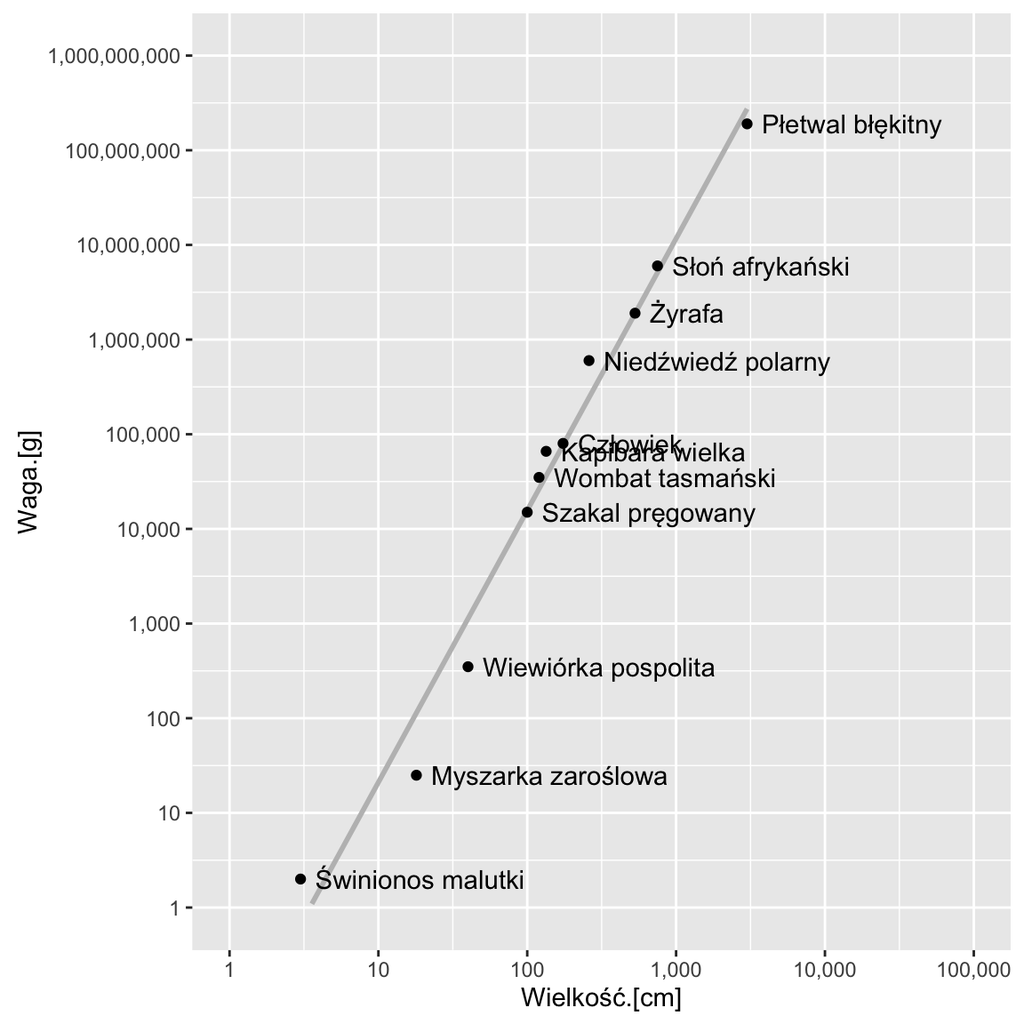

```r
# Czysta mapa
library(ggthemes)
ggplot(ssaki, aes(x=`Wielkość.[cm]`, y=`Waga.[g]`)) +
  geom_point(alpha=0) +
  scale_x_log10(label=comma, limits=c(1,5000), breaks=rep(10^(0:4), 3)*c(1,2,5)) +
  scale_y_log10(label=comma, limits=c(1,10^9), breaks=rep(10^(0:8), 3)*c(1,2,5)) +
  theme_bw()
```

Load: [`archivist::aread('BetaAndBit/PieczaraPietraszki/UniwersytetDzieci/arepo/7dee94c8d4e7349d54f1bde322a82715')`](https://github.com/BetaAndBit/PieczaraPietraszki/blob/master/UniwersytetDzieci/arepo/gallery/7dee94c8d4e7349d54f1bde322a82715.rda?raw=true)

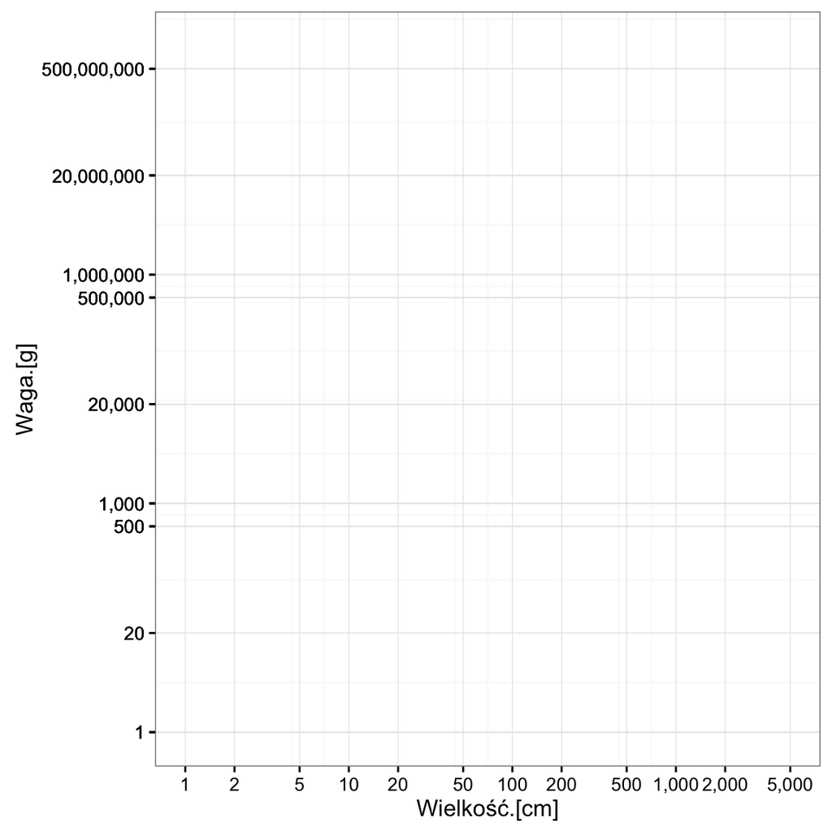

# Psy

Poniższa tabela i wykres przedstawiają zależność wielkości od masy różnych ras psów. Od tych najmniejszych po największe giganty. Zależność jest liniowa w skali log-log.

```r
psy <- read.xlsx("Psy/psy.xlsx", 1)

print(kable(psy))
```

Load: [`archivist::aread('BetaAndBit/PieczaraPietraszki/UniwersytetDzieci/arepo/85c7a5abcf97ff0906a0bdd314b652c5')`](https://github.com/BetaAndBit/PieczaraPietraszki/blob/master/UniwersytetDzieci/arepo/gallery/85c7a5abcf97ff0906a0bdd314b652c5.rda?raw=true)

| Angielska.nazwa | Polska.nazwa | Wysokość | Masa | Odnośnik |
| --- | --- | --- | --- | --- |
| Chihuahua | Chihuahua | 20 | 2.7 | http://www.dogsindepth.com/toy_dog_breeds/chihuahua.html |
| Yorkshire Terrier | Yorkshire Terrier | 22 | 3.0 | http://www.dogsindepth.com/toy_dog_breeds/yorkshire_terrier.html |
| Poodle | Pudel duży | 60 | 24.0 | http://www.dogsindepth.com/nonsporting_dog_breeds/poodle.html |
| Chow Chow | Chow Chow | 55 | 31.0 | http://www.dogsindepth.com/nonsporting_dog_breeds/chow_chow.html |
| Bearded Collie | Bearded collie | 55 | 28.0 | http://www.dogsindepth.com/herding_dog_breeds/bearded_collie.html |
| Japanese Akita | Akita | 70 | 50.0 | http://www.dogsindepth.com/spitz_dog_breeds/japanese_akita.html |
| Black Russian Terrier | Czarny terier rosyjski | 75 | 65.0 | http://www.dogsindepth.com/working_dog_breeds/black_russian_terrier.html |
| Spanish Mastiff | Mastif hiszpański | 80 | 90.0 | http://www.dogsindepth.com/molossoid_dog_breeds/spanish_mastiff.html |
| Tibetan Terrier | Terier tybetański | 40 | 13.0 | http://www.dogsindepth.com/nonsporting_dog_breeds/tibetan_terrier.html |
| Tosa | Tosa | 60 | 55.0 | http://www.dogsindepth.com/molossoid_dog_breeds/tosa.html |
| Newfoundland | Nowofunlandczyk | 71 | 70.0 | http://www.dogsindepth.com/working_dog_breeds/newfoundland.html |

```r
ggplot(psy, aes(x=`Wysokość`, y=`Masa`)) +
  geom_smooth(method="lm", se=FALSE, color="grey") +
  geom_point() + geom_text(aes(label=Polska.nazwa), hjust=0, nudge_x = .03) +
  scale_x_log10(label=comma, limits=c(10,200), breaks=10^(1:2)) +
  scale_y_log10(label=comma, limits=c(1,10^2), breaks=10^(0:2))
```

Load: [`archivist::aread('BetaAndBit/PieczaraPietraszki/UniwersytetDzieci/arepo/6261fec3ed8a1e8303e4b94d9c3ef527')`](https://github.com/BetaAndBit/PieczaraPietraszki/blob/master/UniwersytetDzieci/arepo/gallery/6261fec3ed8a1e8303e4b94d9c3ef527.rda?raw=true)

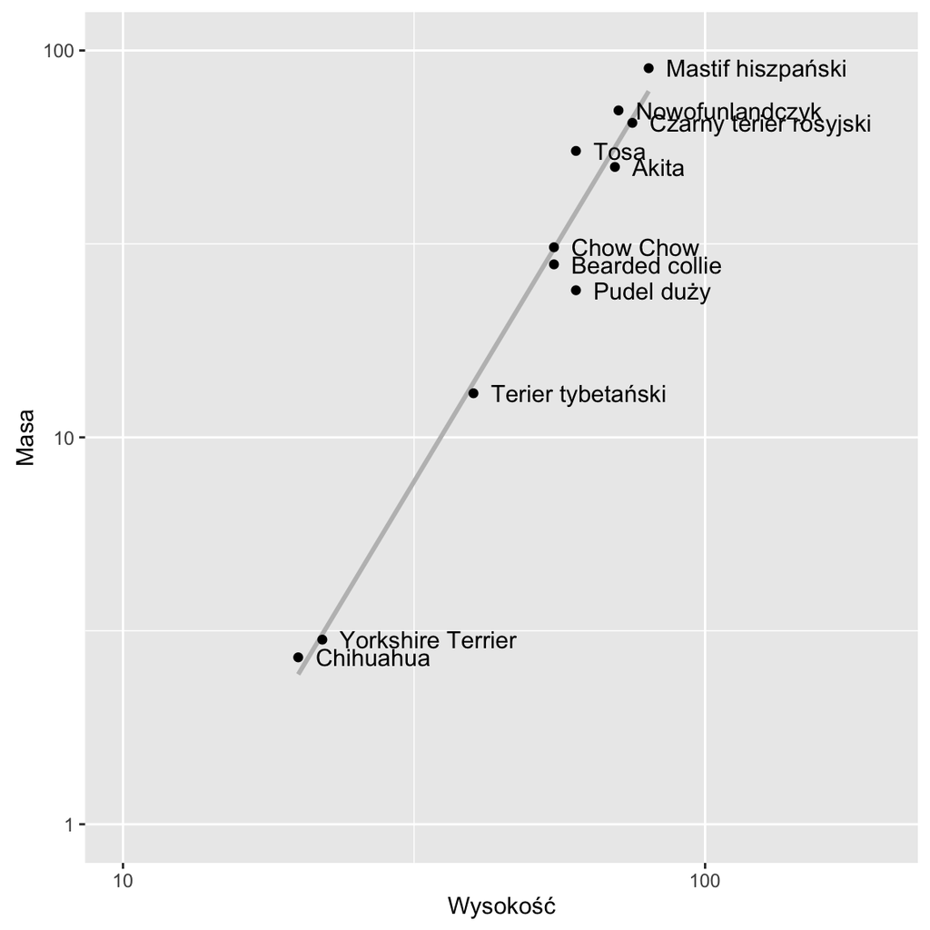

```r
# Czysta

ggplot(psy, aes(x=`Wysokość`, y=`Masa`)) +
  geom_point(alpha=0) +
  scale_x_continuous(label=comma, limits=c(0,100), breaks=seq(0,100,10)) +
  scale_y_continuous(label=comma, limits=c(0,100), breaks=seq(0,100,10)) +
  theme_bw()
```

Load: [`archivist::aread('BetaAndBit/PieczaraPietraszki/UniwersytetDzieci/arepo/1d1a39019213c0df196c83dcf04a54ab')`](https://github.com/BetaAndBit/PieczaraPietraszki/blob/master/UniwersytetDzieci/arepo/gallery/1d1a39019213c0df196c83dcf04a54ab.rda?raw=true)

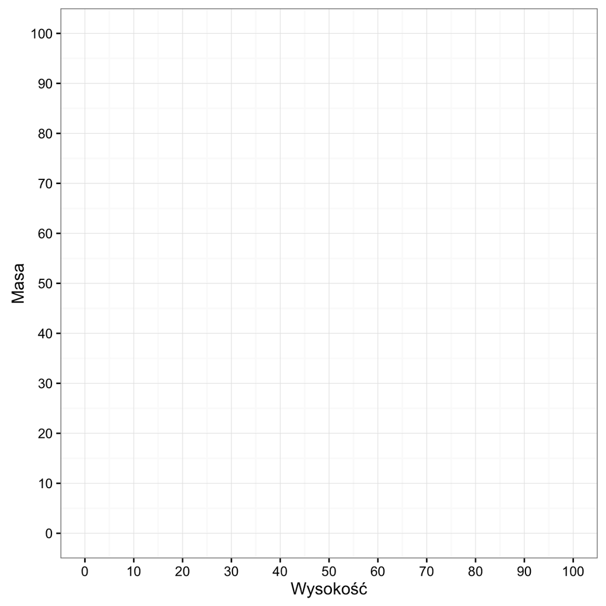

# Sekwoja

Poniższa tabela i wykres przedstawiają zależność wielkości od masy różnych organizmów z opowiadania o sekwojach.

```r
sekwoje <- read.xlsx("Sekwoje/Sekwoje.xlsx", 1)

print(kable(sekwoje))
```

Load: [`archivist::aread('BetaAndBit/PieczaraPietraszki/UniwersytetDzieci/arepo/eda9fb938ba55be848e5393992d1836e')`](https://github.com/BetaAndBit/PieczaraPietraszki/blob/master/UniwersytetDzieci/arepo/gallery/eda9fb938ba55be848e5393992d1836e.rda?raw=true)

| Angielska.nazwa | Polska.nazwa | Wysokość | Masa |
| --- | --- | --- | --- |
| Boy | Chłopiec | 1 | 30 |
| Elephant | Słoń | 4 | 5000 |
| Blue Whale | Wieloryb | 30 | 190000 |
| Sequoia | Sekwoja | 95 | 1900000 |

```r
ggplot(sekwoje, aes(x=`Wysokość`, y=`Masa`)) +
  geom_smooth(method="lm", se=FALSE, color="grey") +
  geom_point() + geom_text(aes(label=Polska.nazwa), hjust=0, nudge_x = .03) +
  scale_x_log10(label=comma, limits=c(0.8,200), breaks=10^(0:2)) +
  scale_y_log10(label=comma, limits=c(10,3*10^6), breaks=10^(0:7))
```

Load: [`archivist::aread('BetaAndBit/PieczaraPietraszki/UniwersytetDzieci/arepo/946bfb7d081312c079257138afefebf7')`](https://github.com/BetaAndBit/PieczaraPietraszki/blob/master/UniwersytetDzieci/arepo/gallery/946bfb7d081312c079257138afefebf7.rda?raw=true)

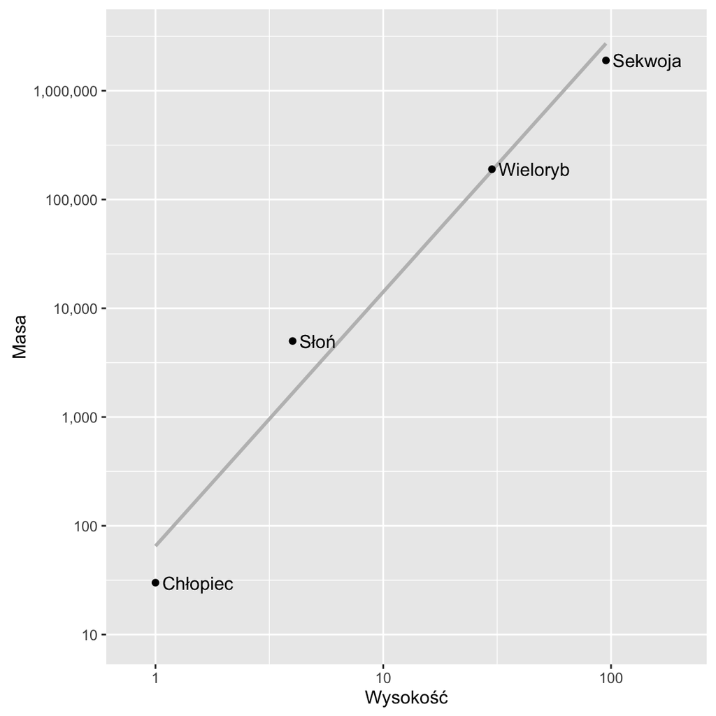